# R Notebook

#GRAM-NEGATIVE AND GRAM-POSITIVE BACTERIA CULTURE

##Activating Libraries

```r
library(readxl)
library(ggpubr)
library(forcats)
library(ggsci)
```

#Import table

```r
setwd("~/OneDrive - Michigan State University/Manning_lab/Mastitis_project/GitHub/data/")
counts_CFU <- read.csv("metadata_full.csv")
counts_CFU$Treatment <- factor(counts_CFU$Treatment, levels = c("Control", "Antibiotic"))
```

#GRAM NEGATIVES

##Difference between day -1 and week 1 within the same treatment group

```r
library(dplyr)
library(rstatix)
`%notin%` <- Negate(`%in%`)

stat.test <- counts_CFU %>%
  dplyr::filter(`GN_CFU.g` %notin% NA, study_ID %notin% "MA027", Time_tx %notin% "Week 11") %>%
  filter(Time_tx %in% c("Week 1", "Day -1")) %>%
  dplyr::group_by(Treatment) %>%
  rstatix::wilcox_test(`GN_CFU.g` ~ Time_tx, alternative = "greater", paired = T) %>%
 rstatix::adjust_pvalue(method = "none") %>%
  rstatix::add_significance("p.adj")
stat.test
```

| Treatment | .y. | group1 | group2 | n1 | n2 | statistic | p | p.adj | p.adj.signif |
| --- | --- | --- | --- | --- | --- | --- | --- | --- | --- |
| Control | GN_CFU.g | Day -1 | Week 1 | 20 | 20 | 109 | 0.449 | 0.449 | ns |
| Antibiotic | GN_CFU.g | Day -1 | Week 1 | 20 | 20 | 127 | 0.215 | 0.215 | ns |

##Difference between treatment groups by time point (day -1, week 1-5), PAIRED TEST

```r
library(dplyr)
library(rstatix)
`%notin%` <- Negate(`%in%`)

stat.test <- counts_CFU %>%
  dplyr::filter(`GN_CFU.g` %notin% NA, study_ID %notin% "MA027", Time_tx %notin% c("Week 11","Week 7","Week 9")) %>% #Filtering MA027 because it was drawn from the study in week 1. Not including weeks 7 and 9 because one animal was drawn from the study in week 7 (see chunk below) and the analysis could not be paired for those weeks. Not including Week 11 because we only took samples of 4 out of 20 animals in that week.
  dplyr::group_by(Time_tx) %>%
  rstatix::wilcox_test(`GN_CFU.g` ~ Treatment, alternative = "greater", paired = T) %>%
 rstatix::adjust_pvalue(method = "none") %>%
  rstatix::add_significance("p.adj")
stat.test
```

| Time_tx | .y. | group1 | group2 | n1 | n2 | statistic | p | p.adj | p.adj.signif |
| --- | --- | --- | --- | --- | --- | --- | --- | --- | --- |
| Day -1 | GN_CFU.g | Control | Antibiotic | 20 | 20 | 157 | 0.02660 | 0.02660 | * |
| Week 1 | GN_CFU.g | Control | Antibiotic | 20 | 20 | 171 | 0.00604 | 0.00604 | ** |
| Week 2 | GN_CFU.g | Control | Antibiotic | 20 | 20 | 104 | 0.52200 | 0.52200 | ns |
| Week 3 | GN_CFU.g | Control | Antibiotic | 20 | 20 | 110 | 0.43500 | 0.43500 | ns |
| Week 5 | GN_CFU.g | Control | Antibiotic | 20 | 20 | 147 | 0.06150 | 0.06150 | ns |

##Difference between treatment groups by time point, weeks 7 and 9 PAIRED (1 cow was draw of the study on week7)

```r
library(dplyr)
library(rstatix)
`%notin%` <- Negate(`%in%`)

stat.test <- counts_CFU %>%
  dplyr::filter(`GN_CFU.g` %notin% NA, study_ID %notin% c("MA027","MA028"), Time_tx %in% c("Week 7","Week 9")) %>% #Filtering MA028 because it was paired with MA029 which was drawn from the study on week 7
  dplyr::group_by(Time_tx) %>%
  rstatix::wilcox_test(`GN_CFU.g` ~ Treatment, alternative = "greater", paired = T) %>%
 rstatix::adjust_pvalue(method = "none") %>%
  rstatix::add_significance("p.adj")
stat.test
```

| Time_tx | .y. | group1 | group2 | n1 | n2 | statistic | p | p.adj | p.adj.signif |
| --- | --- | --- | --- | --- | --- | --- | --- | --- | --- |
| Week 7 | GN_CFU.g | Control | Antibiotic | 19 | 19 | 117 | 0.198 | 0.198 | ns |
| Week 9 | GN_CFU.g | Control | Antibiotic | 19 | 19 | 94 | 0.524 | 0.524 | ns |

##Significance over the time period (regardless of treatment)

```r
stat.test <- counts_CFU %>%
  dplyr::filter(`GN_CFU.g` %notin% NA) %>%
  dplyr::filter(Time_tx %notin% "Week 11") %>%
  kruskal_test(`GN_CFU.g` ~ Time_tx)
stat.test
```

|  | .y. | n | statistic | df | p | method |
| --- | --- | --- | --- | --- | --- | --- |
| 1 | GN_CFU.g | 279 | 13.38559 | 6 | 0.0373 | Kruskal-Wallis |

##Total Gram-negatives plot

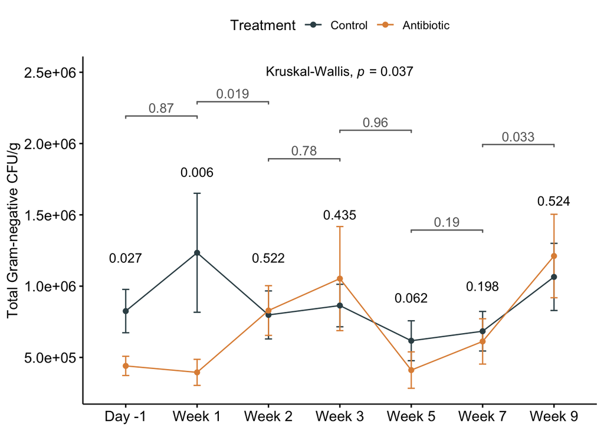

```r
library(ggpubr)
total_line <- counts_CFU %>%
  dplyr::filter(`GN_CFU.g` %notin% NA, study_ID %notin% "MA027", Time_tx %notin% "Week 11") %>%
  ggline(x = "Time_tx", y = "GN_CFU.g", color = "Treatment", add = c("mean_se"),
         ylab = "Total Gram-negative CFU/g", xlab = "Time to treatment", palette = "jama") +
  scale_y_continuous(labels = function(x) format(x, scientific = TRUE)) +
  annotate("text", x = 1, y = 1.2e+06, label = expression("0.027"), colour = "black") +
  annotate("text", x = 2, y = 1.8e+06, label = expression("0.006"), colour = "black") +
  annotate("text", x = 3, y = 1.2e+06, label = expression("0.522"), colour = "black") +
  annotate("text", x = 4, y = 1.5e+06, label = expression("0.435"), colour = "black") +
  annotate("text", x = 5, y = 0.92e+06, label = expression("0.062"), colour = "black") +
  annotate("text", x = 6, y = 1e+06, label = expression("0.198"), colour = "black") +
  annotate("text", x = 7, y = 1.6e+06, label = expression("0.524"), colour = "black") +
  annotate("text", x = 4, y = 2.5e+06, label = expression(paste("Kruskal-Wallis, ", paste(italic('p'))," = 0.037"))) +
  geom_signif(aes(y = `GN_CFU.g`, x = Time_tx),comparisons = list(c("Day -1","Week 1"),
                                                                 c("Week 1","Week 2"),
                                                                 c("Week 2","Week 3"),
                                                                 c("Week 3","Week 5"),
                                                                 c("Week 5","Week 7"),
                                                                 c("Week 7","Week 9")),
              test = "wilcox.test", y_position = c(1.8e+06,1.9e+06,1.5e+06,1.7e+06,1e+06,1.6e+06), color = "gray40", tip_length = 0.002, test.args=list(alternative = "less", var.equal = FALSE, paired=FALSE)) +
  theme(axis.title.x = element_blank())

total_line
```

##Average Total Gram-negatives per week and treatment group

```r
counts_CFU %>%
  dplyr::filter(`GN_CFU.g` %notin% NA, study_ID %notin% "MA027", Time_tx %notin% "Week 11") %>%
  group_by(Treatment, Time_tx) %>%
  summarise(totaGN = mean(`GN_CFU.g`))
```

| Treatment | Time_tx | totaGN |
| --- | --- | --- |
| Control | Day -1 | 825062.4 |
| Control | Week 1 | 1234015.5 |
| Control | Week 2 | 798063.7 |
| Control | Week 3 | 864019.7 |
| Control | Week 5 | 617002.6 |
| Control | Week 7 | 683793.6 |
| Control | Week 9 | 1064663.8 |
| Antibiotic | Day -1 | 440627.9 |
| Antibiotic | Week 1 | 395246.0 |
| Antibiotic | Week 2 | 828884.0 |

[output cut: 4 more lines]

```r
`%notin%` <- Negate(`%in%`)

stat.test <- counts_CFU %>%
  dplyr::filter(`GN_Amp_per` %notin% NA) %>%
  rstatix::kruskal_test(`GN_Amp_per` ~ Time_tx) %>%
 rstatix::adjust_pvalue(method = "none") %>%
  rstatix::add_significance("p.adj")
stat.test
```

| .y. | n | statistic | df | p | method | p.adj | p.adj.signif |
| --- | --- | --- | --- | --- | --- | --- | --- |
| GN_Amp_per | 283 | 30.48557 | 7 | 7.73e-05 | Kruskal-Wallis | 7.73e-05 | **** |

##Difference between treatment groups by time point (day -1, week 1-5), PAIRED TEST

```r
stat.test <- counts_CFU %>%
  dplyr::filter(`GN_Amp_CFU.g` %notin% NA) %>%
  dplyr::filter(`GN_Amp_CFU.g` %notin% NA, study_ID %notin% "MA027", Time_tx %notin% c("Week 11","Week 7","Week 9")) %>% #Filtering MA027 because it was drawn from the study in week 1. Not including weeks 7 and 9 because one animal was drawn from the study in week 7 (see chunk below) and the analysis could not be paired for those weeks. Not including Week 11 because we only took samples of 4 out of 20 animals in that week.
  dplyr::group_by(Time_tx) %>%
  rstatix::wilcox_test(`GN_Amp_CFU.g` ~ Treatment, alternative = "greater", paired = T) %>%
 rstatix::adjust_pvalue(method = "none") %>%
  rstatix::add_significance("p.adj")
stat.test
```

| Time_tx | .y. | group1 | group2 | n1 | n2 | statistic | p | p.adj | p.adj.signif |
| --- | --- | --- | --- | --- | --- | --- | --- | --- | --- |
| Day -1 | GN_Amp_CFU.g | Control | Antibiotic | 20 | 20 | 67.0 | 0.874 | 0.874 | ns |
| Week 1 | GN_Amp_CFU.g | Control | Antibiotic | 20 | 20 | 98.0 | 0.460 | 0.460 | ns |
| Week 2 | GN_Amp_CFU.g | Control | Antibiotic | 20 | 20 | 123.0 | 0.257 | 0.257 | ns |
| Week 3 | GN_Amp_CFU.g | Control | Antibiotic | 20 | 20 | 119.5 | 0.167 | 0.167 | ns |
| Week 5 | GN_Amp_CFU.g | Control | Antibiotic | 20 | 20 | 114.5 | 0.368 | 0.368 | ns |

##Difference between treatment groups by time point (weeks 7-9), PAIRED TEST

```r
stat.test <- counts_CFU %>%
  dplyr::filter(`GN_Amp_CFU.g` %notin% NA) %>%
  dplyr::filter(`GN_Amp_CFU.g` %notin% NA, study_ID %notin% c("MA027","MA028"), Time_tx %in% c("Week 7","Week 9")) %>% #Filtering MA028 because it was paired with MA029 which was drawn from the study on week 7
  dplyr::group_by(Time_tx) %>%
  rstatix::wilcox_test(`GN_Amp_CFU.g` ~ Treatment, alternative = "greater", paired = T) %>%
 rstatix::adjust_pvalue(method = "none") %>%
  rstatix::add_significance("p.adj")
stat.test
```

| Time_tx | .y. | group1 | group2 | n1 | n2 | statistic | p | p.adj | p.adj.signif |
| --- | --- | --- | --- | --- | --- | --- | --- | --- | --- |
| Week 7 | GN_Amp_CFU.g | Control | Antibiotic | 19 | 19 | 103 | 0.381 | 0.381 | ns |
| Week 9 | GN_Amp_CFU.g | Control | Antibiotic | 19 | 19 | 121 | 0.152 | 0.152 | ns |

##GN Amp CFU/g line plot

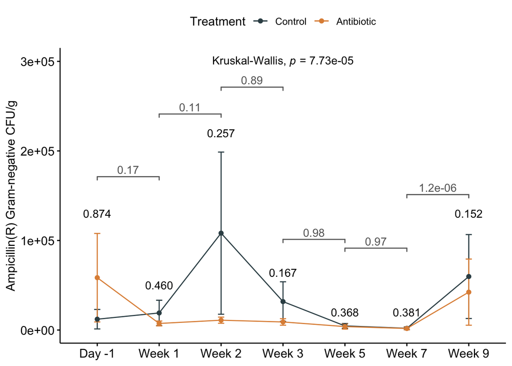

```r
amp_line <- counts_CFU %>%
  dplyr::filter(`GN_Amp_CFU.g` %notin% NA) %>%
  dplyr::filter(study_ID %notin% "MA027") %>%
  dplyr::filter(Time_tx %notin% "Week 11") %>%
  ggline(x = "Time_tx", y = "GN_Amp_CFU.g", color = "Treatment", add = c("mean_se"),  ylab = "Ampicillin(R) Gram-negative CFU/g", xlab = "Time to treatment", palette = "jama") +
  annotate("text", x = 1, y = 1.3e+05, label = expression("0.874"), colour = "black") +
  annotate("text", x = 2, y = 5e+04, label = expression("0.460"), colour = "black") +
  annotate("text", x = 3, y = 2.2e+05, label = expression("0.257"), colour = "black") +
  annotate("text", x = 4, y = 6.4e+04, label = expression("0.167"), colour = "black") +
  annotate("text", x = 5, y = 2e+04, label = expression("0.368"), colour = "black") +
  annotate("text", x = 6, y = 2e+04, label = expression("0.381"), colour = "black") +
  annotate("text", x = 7, y = 1.3e+05, label = expression("0.152"), colour = "black") +
  annotate("text", x = 4, y = 3e+05, label = expression(paste("Kruskal-Wallis, ", paste(italic('p'))," = 7.73e-05"))) +  scale_y_continuous(labels = function(x) format(x, scientific = TRUE)) +
  geom_signif(aes(y = `GN_Amp_CFU.g`, x = Time_tx),comparisons = list(c("Day -1","Week 1"),
                                                                 c("Week 1","Week 2"),
                                                                 c("Week 2","Week 3"),
                                                                 c("Week 3","Week 5"),
                                                                 c("Week 5","Week 7"),
                                                                 c("Week 7","Week 9")),
              test = "wilcox.test", test.args=list(alternative = "less", var.equal = FALSE, paired=FALSE), color = "gray40", tip_length = 0.002, y_position = c(80000,1.5e+05,1.8e+05,10000,2e+02,60000)) +
  theme(axis.title.x = element_blank())


amp_line
```

#Gram-negatives AMPICILLIN resistant percentage (%) Percentage was calculated over the total number of Gram-negative bacteria

##Significance over the time period (regardless of treatment)

```r
library(dplyr)
library(rstatix)
`%notin%` <- Negate(`%in%`)

stat.test <- counts_CFU %>%
  dplyr::filter(`GN_Amp_per` %notin% NA) %>%
  dplyr::filter(study_ID %notin% "MA027") %>%
  rstatix::kruskal_test(`GN_Amp_per` ~ Time_tx) %>%
 rstatix::adjust_pvalue(method = "none") %>%
  rstatix::add_significance("p.adj")
stat.test
```

| .y. | n | statistic | df | p | method | p.adj | p.adj.signif |
| --- | --- | --- | --- | --- | --- | --- | --- |
| GN_Amp_per | 282 | 30.20286 | 7 | 8.72e-05 | Kruskal-Wallis | 8.72e-05 | **** |

##Difference between treatment groups by time point (day -1, week 1-5), PAIRED TEST

```r
stat.test <- counts_CFU %>%
  dplyr::filter(`GN_Amp_per` %notin% NA, study_ID %notin% "MA027", Time_tx %notin% c("Week 11","Week 7","Week 9")) %>% #Filtering MA027 because it was drawn from the study in week 1. Not including weeks 7 and 9 because one animal was drawn from the study in week 7 (see chunk below) and the analysis could not be paired for those weeks. Not including Week 11 because we only took samples of 4 out of 20 animals in that week.
  dplyr::group_by(Time_tx) %>%
  rstatix::wilcox_test(`GN_Amp_per` ~ Treatment, alternative = "less", paired = T) %>%
 rstatix::adjust_pvalue(method = "none") %>%
  rstatix::add_significance("p.adj")
stat.test
```

| Time_tx | .y. | group1 | group2 | n1 | n2 | statistic | p | p.adj | p.adj.signif |
| --- | --- | --- | --- | --- | --- | --- | --- | --- | --- |
| Day -1 | GN_Amp_per | Control | Antibiotic | 20 | 20 | 25.0 | 0.00258 | 0.00258 | ** |
| Week 1 | GN_Amp_per | Control | Antibiotic | 20 | 20 | 86.0 | 0.24500 | 0.24500 | ns |
| Week 2 | GN_Amp_per | Control | Antibiotic | 20 | 20 | 126.0 | 0.78500 | 0.78500 | ns |
| Week 3 | GN_Amp_per | Control | Antibiotic | 20 | 20 | 119.0 | 0.70200 | 0.70200 | ns |
| Week 5 | GN_Amp_per | Control | Antibiotic | 20 | 20 | 80.5 | 0.18500 | 0.18500 | ns |

##Difference between treatment groups by time point (weeks 7-9), PAIRED TEST

```r
stat.test <- counts_CFU %>%
  dplyr::filter(`GN_Amp_per` %notin% NA) %>%
  dplyr::filter(`GN_Amp_per` %notin% NA, study_ID %notin% c("MA027","MA028"), Time_tx %in% c("Week 7","Week 9")) %>% #Filtering MA028 because it was paired with MA029 which was drawn from the study on week 7
  dplyr::group_by(Time_tx) %>%
  rstatix::wilcox_test(`GN_Amp_per` ~ Treatment, alternative = "less", paired = T) %>%
 rstatix::adjust_pvalue(method = "none") %>%
  rstatix::add_significance("p.adj")
stat.test
```

| Time_tx | .y. | group1 | group2 | n1 | n2 | statistic | p | p.adj | p.adj.signif |
| --- | --- | --- | --- | --- | --- | --- | --- | --- | --- |
| Week 7 | GN_Amp_per | Control | Antibiotic | 19 | 19 | 76.5 | 0.234 | 0.234 | ns |
| Week 9 | GN_Amp_per | Control | Antibiotic | 19 | 19 | 95.5 | 0.516 | 0.516 | ns |

##GN Amp percentage line plot

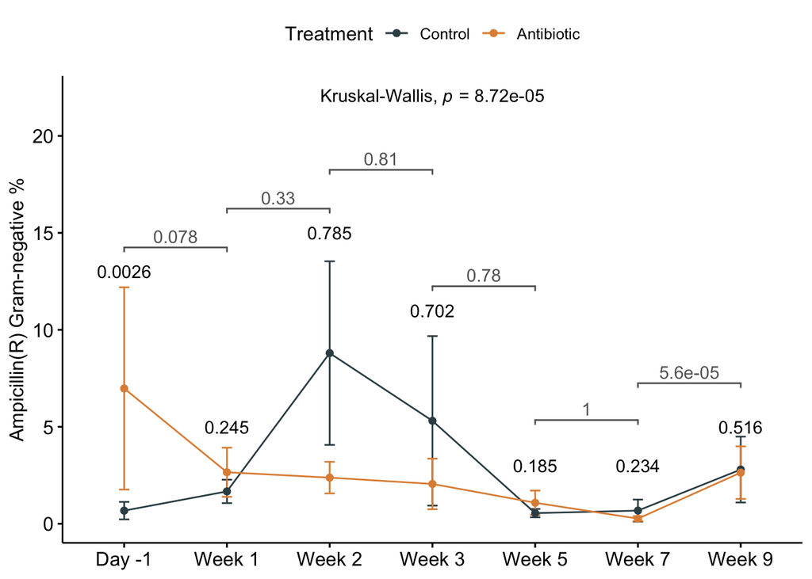

```r
amp_line_per <- counts_CFU %>%
  dplyr::filter(`GN_Amp_per` %notin% NA) %>%
  dplyr::filter(study_ID %notin% "MA027") %>%
  dplyr::filter(Time_tx %notin% "Week 11") %>%
  ggline(x = "Time_tx", y = "GN_Amp_per", color = "Treatment", add = c("mean_se"),  ylab = "Ampicillin(R) Gram-negative %", xlab = "Time to treatment", palette = "jama") +
  annotate("text", x = 1, y = 13, label = expression("0.0026"), colour = "black") +
  annotate("text", x = 2, y = 5, label = expression("0.245"), colour = "black") +
  annotate("text", x = 3, y = 15, label = expression("0.785"), colour = "black") +
  annotate("text", x = 4, y = 11, label = expression("0.702"), colour = "black") +
  annotate("text", x = 5, y = 3, label = expression("0.185"), colour = "black") +
  annotate("text", x = 6, y = 3, label = expression("0.234"), colour = "black") +
  annotate("text", x = 7, y = 5, label = expression("0.516"), colour = "black") +
  annotate("text", x = 4, y = 22, label = expression(paste("Kruskal-Wallis, ", paste(italic('p'))," = 8.72e-05"))) +
  geom_signif(aes(y = `GN_Amp_per`, x = Time_tx),comparisons = list(c("Day -1","Week 1"),
                                                                 c("Week 1","Week 2"),
                                                                 c("Week 2","Week 3"),
                                                                 c("Week 3","Week 5"),
                                                                 c("Week 5","Week 7"),
                                                                 c("Week 7","Week 9")),
              test = "wilcox.test", test.args=list(alternative  = "less", var.equal = FALSE, paired=FALSE), color = "gray40", tip_length = 0.002, y_position = c(9,11,13,7,.1,2)) +
  theme(axis.title.x = element_blank())


amp_line_per
```

```r
`%notin%` <- Negate(`%in%`)

stat.test <- counts_CFU %>%
  dplyr::filter(`GN_Cef_per` %notin% NA) %>%
  rstatix::kruskal_test(`GN_Cef_per` ~ Time_tx) %>%
 rstatix::adjust_pvalue(method = "none") %>%
  rstatix::add_significance("p.adj")
stat.test
```

| .y. | n | statistic | df | p | method | p.adj | p.adj.signif |
| --- | --- | --- | --- | --- | --- | --- | --- |
| GN_Cef_per | 283 | 22.3512 | 7 | 0.00221 | Kruskal-Wallis | 0.00221 | ** |

##Average by time point

```r
counts_CFU %>%
  dplyr::filter(`GN_Cef_CFU.g` %notin% NA, study_ID %notin% "MA027") %>%
  group_by(Time_tx, Treatment) %>%
  summarise(`Ceftiofur_CFU/g` = mean(`GN_Cef_CFU.g`))
```

| Time_tx | Treatment | Ceftiofur_CFU/g |
| --- | --- | --- |
| Day -1 | Control | 125.10450 |
| Day -1 | Antibiotic | 166.50150 |
| Week 1 | Control | 24.15800 |
| Week 1 | Antibiotic | 196.72200 |
| Week 11 | Control | 0.00000 |
| Week 11 | Antibiotic | 12.50000 |
| Week 2 | Control | 14.38450 |
| Week 2 | Antibiotic | 335.11000 |
| Week 3 | Control | 10.42300 |
| Week 3 | Antibiotic | 9.38450 |

[output cut: 6 more lines]

##Difference between treatment groups by time point (day -1, week 1-5), PAIRED TEST

```r
stat.test <- counts_CFU %>%
  dplyr::filter(`GN_Cef_CFU.g` %notin% NA, study_ID %notin% "MA027", Time_tx %notin% c("Week 11","Week 7","Week 9")) %>% #Filtering MA027 because it was drawn from the study in week 1. Not including weeks 7 and 9 because one animal was drawn from the study in week 7 (see chunk below) and the analysis could not be paired for those weeks. Not including Week 11 because we only took samples of 4 out of 20 animals in that week.
  dplyr::group_by(Time_tx) %>%
  rstatix::wilcox_test(`GN_Cef_CFU.g` ~ Treatment, alternative = "less", paired = T) %>%
 rstatix::adjust_pvalue(method = "none") %>%
  rstatix::add_significance("p.adj")
stat.test
```

| Time_tx | .y. | group1 | group2 | n1 | n2 | statistic | p | p.adj | p.adj.signif |
| --- | --- | --- | --- | --- | --- | --- | --- | --- | --- |
| Day -1 | GN_Cef_CFU.g | Control | Antibiotic | 20 | 20 | 27.0 | 0.723 | 0.723 | ns |
| Week 1 | GN_Cef_CFU.g | Control | Antibiotic | 20 | 20 | 17.0 | 0.277 | 0.277 | ns |
| Week 2 | GN_Cef_CFU.g | Control | Antibiotic | 20 | 20 | 20.5 | 0.254 | 0.254 | ns |
| Week 3 | GN_Cef_CFU.g | Control | Antibiotic | 20 | 20 | 14.5 | 0.568 | 0.568 | ns |
| Week 5 | GN_Cef_CFU.g | Control | Antibiotic | 20 | 20 | 3.0 | 0.963 | 0.963 | ns |

##Difference between treatment groups by time point (weeks 7-9), PAIRED TEST

```r
stat.test <- counts_CFU %>%
  dplyr::filter(`GN_Cef_CFU.g` %notin% NA) %>%
  dplyr::filter(`GN_Cef_CFU.g` %notin% NA, study_ID %notin% c("MA027","MA028"), Time_tx %in% c("Week 7","Week 9")) %>% #Filtering MA028 because it was paired with MA029 which was drawn from the study on week 7
  dplyr::group_by(Time_tx) %>%
  rstatix::wilcox_test(`GN_Cef_CFU.g` ~ Treatment, alternative = "less", paired = T) %>%
 rstatix::adjust_pvalue(method = "none") %>%
  rstatix::add_significance("p.adj")
stat.test
```

| Time_tx | .y. | group1 | group2 | n1 | n2 | statistic | p | p.adj | p.adj.signif |
| --- | --- | --- | --- | --- | --- | --- | --- | --- | --- |
| Week 7 | GN_Cef_CFU.g | Control | Antibiotic | 19 | 19 | 16 | 0.664 | 0.664 | ns |
| Week 9 | GN_Cef_CFU.g | Control | Antibiotic | 19 | 19 | 42 | 0.991 | 0.991 | ns |

##Ceftiofur CFU/g plot

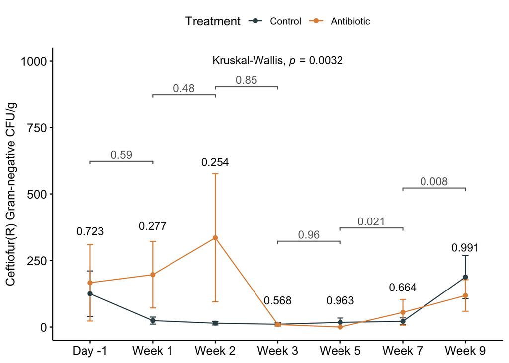

```r
cef_line <- counts_CFU %>%
  dplyr::filter(`GN_Cef_CFU.g` %notin% NA) %>%
  dplyr::filter(study_ID %notin% "MA027") %>%
  dplyr::filter(Time_tx %notin% "Week 11") %>%
  ggline(x = "Time_tx", y = "GN_Cef_CFU.g", color = "Treatment", add = c("mean_se"),  ylab = "Ceftiofur(R) Gram-negative CFU/g", xlab = "Time to treatment", palette = "jama") +
  annotate("text", x = 1, y = 360, label = expression("0.723"), colour = "black") +
  annotate("text", x = 2, y = 380, label = expression("0.277"), colour = "black") +
  annotate("text", x = 3, y = 620, label = expression("0.254"), colour = "black") +
  annotate("text", x = 4, y = 100, label = expression("0.568"), colour = "black") +
  annotate("text", x = 5, y = 100, label = expression("0.963"), colour = "black") +
  annotate("text", x = 6, y = 150, label = expression("0.664"), colour = "black") +
  annotate("text", x = 7, y = 300, label = expression("0.991"), colour = "black") +
  annotate("text", x = 4, y = 1000, label = expression(paste("Kruskal-Wallis, ", paste(italic('p'))," = 0.0032"))) +
  geom_signif(aes(y = `GN_Cef_CFU.g`, x = Time_tx),comparisons = list(c("Day -1","Week 1"),
                                                                 c("Week 1","Week 2"),
                                                                 c("Week 2","Week 3"),
                                                                 c("Week 3","Week 5"),
                                                                 c("Week 5","Week 7"),
                                                                 c("Week 7","Week 9")),
              test = "wilcox.test", test.args=list(alternative = "less", var.equal = FALSE, paired=FALSE), color = "gray40", tip_length = 0.002, y_position = c(400,650,680,100,150,300)) +
  theme(axis.title.x = element_blank())


cef_line
```

#Gram-negatives CEFTIOFUR resistant percentage (%) Percentage was calculated over the total number of Gram-negative bacteria ##Significance over the time period (regardless of treatment)

```r
library(dplyr)
library(rstatix)
`%notin%` <- Negate(`%in%`)

stat.test <- counts_CFU %>%
  dplyr::filter(`GN_Cef_per` %notin% NA) %>%
  rstatix::kruskal_test(`GN_Cef_per` ~ Time_tx) %>%
 rstatix::adjust_pvalue(method = "none") %>%
  rstatix::add_significance("p.adj")
stat.test
```

| .y. | n | statistic | df | p | method | p.adj | p.adj.signif |
| --- | --- | --- | --- | --- | --- | --- | --- |
| GN_Cef_per | 283 | 22.3512 | 7 | 0.00221 | Kruskal-Wallis | 0.00221 | ** |

##Difference between treatment groups by time point (day -1, week 1-5), PAIRED TEST

```r
stat.test <- counts_CFU %>%
  dplyr::filter(`GN_Cef_per` %notin% NA, study_ID %notin% "MA027", Time_tx %notin% c("Week 11","Week 7","Week 9")) %>% #Filtering MA027 because it was drawn from the study in week 1. Not including weeks 7 and 9 because one animal was drawn from the study in week 7 (see chunk below) and the analysis could not be paired for those weeks. Not including Week 11 because we only took samples of 4 out of 20 animals in that week.
  dplyr::group_by(Time_tx) %>%
  rstatix::wilcox_test(`GN_Cef_per` ~ Treatment, alternative = "less", paired = T) %>%
 rstatix::adjust_pvalue(method = "none") %>%
  rstatix::add_significance("p.adj")
stat.test
```

| Time_tx | .y. | group1 | group2 | n1 | n2 | statistic | p | p.adj | p.adj.signif |
| --- | --- | --- | --- | --- | --- | --- | --- | --- | --- |
| Day -1 | GN_Cef_per | Control | Antibiotic | 20 | 20 | 14 | 0.534 | 0.534 | ns |
| Week 1 | GN_Cef_per | Control | Antibiotic | 20 | 20 | 11 | 0.336 | 0.336 | ns |
| Week 2 | GN_Cef_per | Control | Antibiotic | 20 | 20 | 3 | 0.290 | 0.290 | ns |
| Week 3 | GN_Cef_per | Control | Antibiotic | 20 | 20 | 4 | 0.807 | 0.807 | ns |
| Week 5 | GN_Cef_per | Control | Antibiotic | 20 | 20 | 1 | 0.977 | 0.977 | ns |

##Difference between treatment groups by time point (weeks 7-9), PAIRED TEST

```r
stat.test <- counts_CFU %>%
  dplyr::filter(`GN_Cef_per` %notin% NA) %>%
  dplyr::filter(`GN_Cef_per` %notin% NA, study_ID %notin% c("MA027","MA028"), Time_tx %in% c("Week 7","Week 9")) %>% #Filtering MA028 because it was paired with MA029 which was drawn from the study on week 7
  dplyr::group_by(Time_tx) %>%
  rstatix::wilcox_test(`GN_Cef_per` ~ Treatment, alternative = "less", paired = T) %>%
 rstatix::adjust_pvalue(method = "none") %>%
  rstatix::add_significance("p.adj")
stat.test
```

| Time_tx | .y. | group1 | group2 | n1 | n2 | statistic | p | p.adj | p.adj.signif |
| --- | --- | --- | --- | --- | --- | --- | --- | --- | --- |
| Week 7 | GN_Cef_per | Control | Antibiotic | 19 | 19 | 1.5 | 0.135 | 0.135 | ns |
| Week 9 | GN_Cef_per | Control | Antibiotic | 19 | 19 | 24.5 | 0.838 | 0.838 | ns |

##GN Ceftiofur resistant percentage line plot

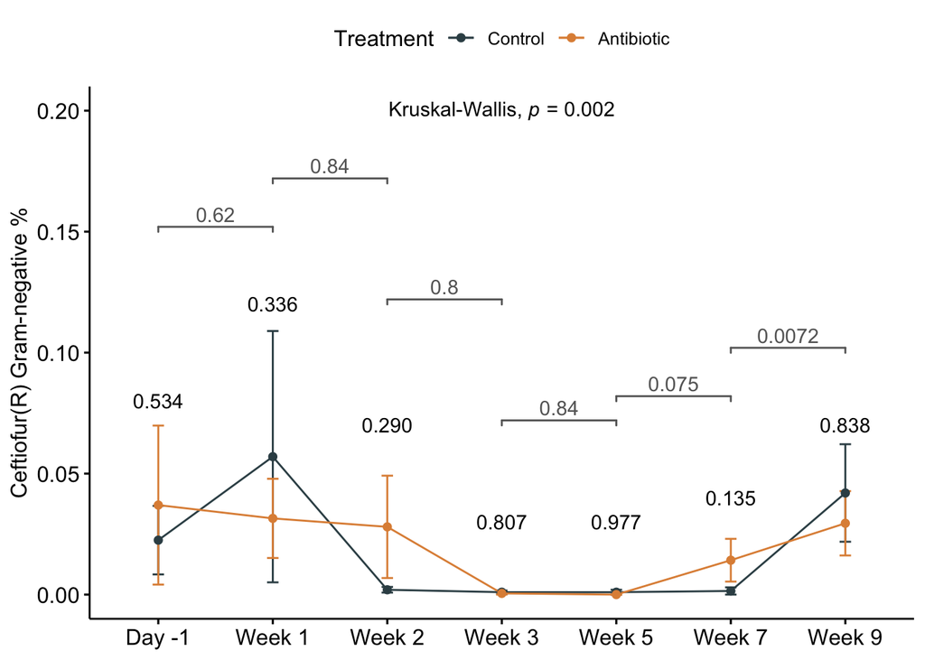

```r
cef_line_per <- counts_CFU %>%
  dplyr::filter(`GN_Cef_per` %notin% NA) %>%
  dplyr::filter(study_ID %notin% "MA027") %>%
  dplyr::filter(Time_tx %notin% "Week 11") %>%
  ggline(x = "Time_tx", y = "GN_Cef_per", color = "Treatment", add = c("mean_se"),  ylab = "Ceftiofur(R) Gram-negative %", xlab = "Time to treatment", palette = "jama") +
  annotate("text", x = 1, y = .08, label = expression("0.534"), colour = "black") +
  annotate("text", x = 2, y = .12, label = expression("0.336"), colour = "black") +
  annotate("text", x = 3, y = .07, label = expression("0.290"), colour = "black") +
  annotate("text", x = 4, y = .03, label = expression("0.807"), colour = "black") +
  annotate("text", x = 5, y = .03, label = expression("0.977"), colour = "black") +
  annotate("text", x = 6, y = .04, label = expression("0.135"), colour = "black") +
  annotate("text", x = 7, y = .07, label = expression("0.838"), colour = "black") +
  annotate("text", x = 4, y = .20, label = expression(paste("Kruskal-Wallis, ", paste(italic('p'))," = 0.002"))) +
  geom_signif(aes(y = `GN_Cef_per`, x = Time_tx),comparisons = list(c("Day -1","Week 1"),
                                                                 c("Week 1","Week 2"),
                                                                 c("Week 2","Week 3"),
                                                                 c("Week 3","Week 5"),
                                                                 c("Week 5","Week 7"),
                                                                 c("Week 7","Week 9")),
              test = "wilcox.test", test.args=list(alternative = "less", var.equal = FALSE, paired=FALSE), color = "gray40", tip_length = 0.002, y_position = c(.10,.12,.07,.02,.03,.05)) +
  theme(axis.title.x = element_blank())


cef_line_per
```

#GRAM POSITIVES total

#Average Gram-positives by treatment and time point

```r
counts_CFU %>%
  dplyr::filter(`GP_CFU.g` %notin% NA, study_ID %notin% "MA027", Time_tx %notin% "Week 11") %>%
  group_by(Treatment, Time_tx) %>%
  summarise(totaGN = mean(`GP_CFU.g`))
```

| Treatment | Time_tx | totaGN |
| --- | --- | --- |
| Control | Day -1 | 749400 |
| Control | Week 1 | 1555200 |
| Antibiotic | Day -1 | 719150 |
| Antibiotic | Week 1 | 620050 |

##Difference between time-points per treatment group

```r
library(dplyr)
library(rstatix)
`%notin%` <- Negate(`%in%`)

stat.test <- counts_CFU %>%
  dplyr::filter(`GP_CFU.g` %notin% NA) %>%
  dplyr::filter(study_ID %notin% "MA027") %>%
  dplyr::group_by(Treatment) %>%
  rstatix::wilcox_test(`GP_CFU.g` ~ Time_tx, alternative = "g", paired = T) %>%
    rstatix::adjust_pvalue(method = "none") %>%
  rstatix::add_significance("p")
stat.test
```

| Treatment | .y. | group1 | group2 | n1 | n2 | statistic | p | p.adj | p.signif |
| --- | --- | --- | --- | --- | --- | --- | --- | --- | --- |
| Control | GP_CFU.g | Day -1 | Week 1 | 20 | 20 | 62 | 0.9470 | 0.9470 | ns |
| Antibiotic | GP_CFU.g | Day -1 | Week 1 | 20 | 20 | 131 | 0.0766 | 0.0766 | ns |

##Difference between treatments by time point

```r
library(dplyr)
library(rstatix)
`%notin%` <- Negate(`%in%`)

stat.test <- counts_CFU %>%
  dplyr::filter(`GP_CFU.g` %notin% NA) %>%
  dplyr::filter(study_ID %notin% "MA027") %>%
  dplyr::filter(Time_tx %in% c("Day -1", "Week 1")) %>%
  dplyr::group_by(Time_tx) %>%
  rstatix::wilcox_test(`GP_CFU.g` ~ Treatment, alternative = "greater", paired = T) %>%
    rstatix::adjust_pvalue(method = "none") %>%
  rstatix::add_significance("p") %>%
  add_xy_position(x = "Time_tx", dodge = 0.8)
stat.test
```

| Time_tx | .y. | group1 | group2 | n1 | n2 | statistic | p | p.adj | p.signif | y.position | groups | x | xmin | xmax |
| --- | --- | --- | --- | --- | --- | --- | --- | --- | --- | --- | --- | --- | --- | --- |
| Day -1 | GP_CFU.g | Control | Antibiotic | 20 | 20 | 104 | 0.5220 | 0.5220 | ns | 3823200 |  | 1 | 0.8 | 1.2 |
| Week 1 | GP_CFU.g | Control | Antibiotic | 20 | 20 | 146 | 0.0664 | 0.0664 | ns | 8193200 |  | 2 | 1.8 | 2.2 |

##Total Gram-positives plot

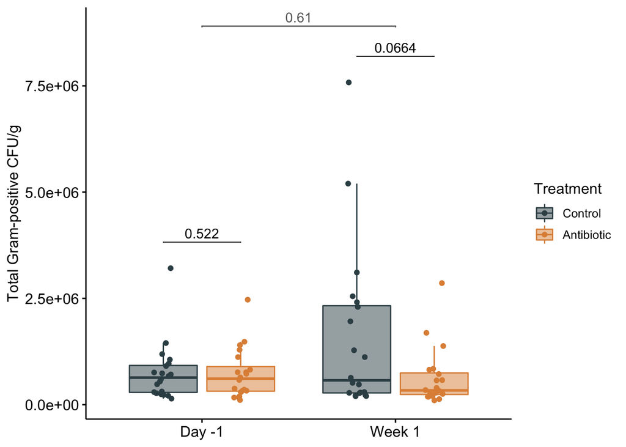

```r
library(ggpubr)
library(ggsci)
GPtotal_boxplot = counts_CFU %>%
  dplyr::filter(`GP_CFU.g` %notin% NA) %>%
  dplyr::filter(study_ID %notin% "MA027") %>%
  ggboxplot(x = "Time_tx", y = "GP_CFU.g", color = "Treatment", palette = "jama",
            fill = "Treatment", add = c("jitter"), notch = F, outlier.shape = NA) +
  labs(x = "Time to treatment", y = "Total Gram-positive CFU/g") +
  scale_fill_jama(alpha = 0.5) +
  theme(legend.position="right") +
  scale_y_continuous(labels = function(x) format(x, scientific = TRUE)) +
  stat_pvalue_manual(stat.test,  label = "p", tip.length = 0) +
  geom_signif(aes(y = `GP_CFU.g`, x = Time_tx),
              comparisons = list(c("Day -1","Week 1")),
              test = "wilcox.test", test.args=list(alternative = "less", var.equal = FALSE, paired=FALSE), color = "gray40", tip_length = 0.002, y_position = c(8.5e+06)) +
  theme(axis.title.x = element_blank())
GPtotal_boxplot
```

#GRAM POSITIVES Ceftiofur resistant CFU/g ##Average Gram-positives resistant to ceftiofur by treatment and time point

```r
counts_CFU %>%
  dplyr::filter(`GP_Cef_CFU.g` %notin% NA, study_ID %notin% "MA027", Time_tx %notin% "Week 11") %>%
  group_by(Treatment, Time_tx) %>%
  summarise(totaGN = mean(`GP_Cef_CFU.g`))
```

| Treatment | Time_tx | totaGN |
| --- | --- | --- |
| Control | Day -1 | 131970 |
| Control | Week 1 | 196015 |
| Antibiotic | Day -1 | 163270 |
| Antibiotic | Week 1 | 135980 |

##Difference between time-points per treatment group

```r
library(dplyr)
library(rstatix)
`%notin%` <- Negate(`%in%`)

stat.test <- counts_CFU %>%
  dplyr::filter(`GP_Cef_CFU.g` %notin% NA) %>%
  dplyr::filter(study_ID %notin% "MA027") %>%
  dplyr::group_by(Treatment) %>%
  rstatix::wilcox_test(`GP_Cef_CFU.g` ~ Time_tx, alternative = "g", paired = T) %>%
    rstatix::adjust_pvalue(method = "none") %>%
  rstatix::add_significance("p")
stat.test
```

| Treatment | .y. | group1 | group2 | n1 | n2 | statistic | p | p.adj | p.signif |
| --- | --- | --- | --- | --- | --- | --- | --- | --- | --- |
| Control | GP_Cef_CFU.g | Day -1 | Week 1 | 20 | 20 | 67 | 0.874 | 0.874 | ns |
| Antibiotic | GP_Cef_CFU.g | Day -1 | Week 1 | 20 | 20 | 111 | 0.420 | 0.420 | ns |

##Difference between treatments by time point

```r
library(dplyr)
library(rstatix)
`%notin%` <- Negate(`%in%`)

stat.test <- counts_CFU %>%
  dplyr::filter(`GP_Cef_CFU.g` %notin% NA) %>%
  dplyr::filter(study_ID %notin% "MA027") %>%
  dplyr::filter(Time_tx %in% c("Day -1", "Week 1")) %>%
  dplyr::group_by(Time_tx) %>%
  rstatix::wilcox_test(`GP_Cef_CFU.g` ~ Treatment, alternative = "greater", paired = T) %>%
    rstatix::adjust_pvalue(method = "none") %>%
  rstatix::add_significance("p") %>%
  add_xy_position(x = "Time_tx", dodge = 0.8)
stat.test
```

| Time_tx | .y. | group1 | group2 | n1 | n2 | statistic | p | p.adj | p.signif | y.position | groups | x | xmin | xmax |
| --- | --- | --- | --- | --- | --- | --- | --- | --- | --- | --- | --- | --- | --- | --- |
| Day -1 | GP_Cef_CFU.g | Control | Antibiotic | 20 | 20 | 88 | 0.6190 | 0.6190 | ns | 760960 |  | 1 | 0.8 | 1.2 |
| Week 1 | GP_Cef_CFU.g | Control | Antibiotic | 20 | 20 | 145 | 0.0715 | 0.0715 | ns | 571960 |  | 2 | 1.8 | 2.2 |

##Boxplot

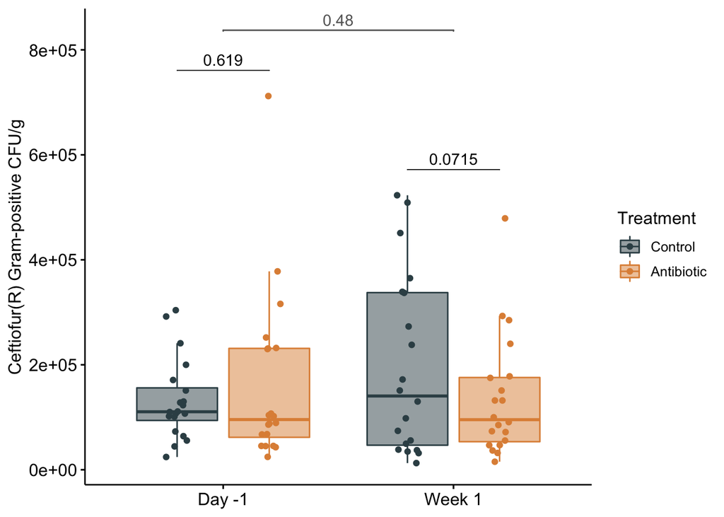

```r
library(ggpubr)
library(ggsci)
GPcef_boxplot = counts_CFU %>%
  dplyr::filter(`GP_Cef_CFU.g` %notin% NA) %>%
  dplyr::filter(study_ID %notin% "MA027") %>%
  ggboxplot(x = "Time_tx", y = "GP_Cef_CFU.g", color = "Treatment", palette = "jama",
            fill = "Treatment", add = c("jitter"), notch = F, outlier.shape = NA) +
  labs(x = "Time to treatment", y = "Ceftiofur(R) Gram-positive CFU/g") +
  scale_fill_jama(alpha = 0.5) + theme(legend.position="right") +
  scale_y_continuous(labels = function(x) format(x, scientific = TRUE)) +
  theme(axis.title.x = element_blank()) +
  stat_pvalue_manual(stat.test,  label = "p", tip.length = 0) +
  geom_signif(aes(y = `GP_Cef_CFU.g`, x = Time_tx),
              comparisons = list(c("Day -1","Week 1")),
              test = "wilcox.test", test.args=list(alternative = "less", var.equal = FALSE, paired=FALSE), color = "gray40", tip_length = 0.002, y_position = c(8e+05))
GPcef_boxplot
```

#GP ceftiofur percentage Percentage calculated over the total of Gram-positive per sample

##Average Gram-positives resistant to ceftiofur by treatment and time point

```r
counts_CFU %>%
  dplyr::filter(`GP_Cef_per` %notin% NA, study_ID %notin% "MA027", Time_tx %notin% "Week 11") %>%
  group_by(Treatment, Time_tx) %>%
  summarise(totaGN = mean(`GP_Cef_per`))
```

| Treatment | Time_tx | totaGN |
| --- | --- | --- |
| Control | Day -1 | 24.2405 |
| Control | Week 1 | 28.2235 |
| Antibiotic | Day -1 | 27.6425 |
| Antibiotic | Week 1 | 32.5520 |

##Difference between time-points per treatment group

```r
library(dplyr)
library(rstatix)
`%notin%` <- Negate(`%in%`)

stat.test <- counts_CFU %>%
  dplyr::filter(`GP_Cef_per` %notin% NA) %>%
  dplyr::filter(study_ID %notin% "MA027") %>%
  dplyr::group_by(Treatment) %>%
  rstatix::wilcox_test(`GP_Cef_per` ~ Time_tx, alternative = "g", paired = T) %>%
    rstatix::adjust_pvalue(method = "none") %>%
  rstatix::add_significance("p")
stat.test
```

| Treatment | .y. | group1 | group2 | n1 | n2 | statistic | p | p.adj | p.signif |
| --- | --- | --- | --- | --- | --- | --- | --- | --- | --- |
| Control | GP_Cef_per | Day -1 | Week 1 | 20 | 20 | 90 | 0.715 | 0.715 | ns |
| Antibiotic | GP_Cef_per | Day -1 | Week 1 | 20 | 20 | 84 | 0.785 | 0.785 | ns |

##Difference between treatments by time point

```r
library(dplyr)
library(rstatix)
`%notin%` <- Negate(`%in%`)

stat.test <- counts_CFU %>%
  dplyr::filter(`GP_Cef_per` %notin% NA) %>%
  dplyr::filter(study_ID %notin% "MA027") %>%
  dplyr::filter(Time_tx %in% c("Day -1", "Week 1")) %>%
  dplyr::group_by(Time_tx) %>%
  rstatix::wilcox_test(`GP_Cef_per` ~ Treatment, alternative = "less", paired = T) %>%
    rstatix::adjust_pvalue(method = "none") %>%
  rstatix::add_significance("p") %>%
  add_xy_position(x = "Time_tx", dodge = 0.8)
stat.test
```

| Time_tx | .y. | group1 | group2 | n1 | n2 | statistic | p | p.adj | p.signif | y.position | groups | x | xmin | xmax |
| --- | --- | --- | --- | --- | --- | --- | --- | --- | --- | --- | --- | --- | --- | --- |
| Day -1 | GP_Cef_per | Control | Antibiotic | 20 | 20 | 93 | 0.337 | 0.337 | ns | 81.6064 |  | 1 | 0.8 | 1.2 |
| Week 1 | GP_Cef_per | Control | Antibiotic | 20 | 20 | 92 | 0.324 | 0.324 | ns | 85.9764 |  | 2 | 1.8 | 2.2 |

##Boxplot

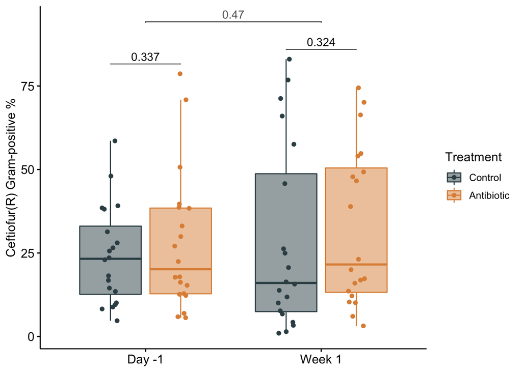

```r
library(ggpubr)
library(ggsci)
GPcef_boxplot_per = counts_CFU %>%
  dplyr::filter(`GP_Cef_per` %notin% NA) %>%
  dplyr::filter(study_ID %notin% "MA027") %>%
  ggboxplot(x = "Time_tx", y = "GP_Cef_per", color = "Treatment", palette = "jama",
            fill = "Treatment", add = c("jitter"), notch = F, outlier.shape = NA) +
  labs(x = "Time to treatment", y = "Ceftiofur(R) Gram-positive %") +
  scale_fill_jama(alpha = 0.5) +
  theme(legend.position="right") +
  theme(axis.title.x = element_blank()) +
  stat_pvalue_manual(stat.test,  label = "p", tip.length = 0) +
  geom_signif(aes(y = `GP_Cef_per`, x = Time_tx),
              comparisons = list(c("Day -1","Week 1")),
              test = "wilcox.test", test.args=list(alternative = "less", var.equal = FALSE, paired=FALSE),
              color = "gray40", tip_length = 0.002, y_position = c(90))
GPcef_boxplot_per
```

#GP Ampicillin CFU/g

##Average Gram-positives resistant to ampicillin by treatment and time point

```r
counts_CFU %>%
  dplyr::filter(`GP_Amp_CFU.g` %notin% NA, study_ID %notin% "MA027", Time_tx %notin% "Week 11") %>%
  group_by(Treatment, Time_tx) %>%
  summarise(totaGN = mean(`GP_Amp_CFU.g`))
```

| Treatment | Time_tx | totaGN |
| --- | --- | --- |
| Control | Day -1 | 21499.50 |
| Control | Week 1 | 28713.75 |
| Antibiotic | Day -1 | 18614.50 |
| Antibiotic | Week 1 | 33598.00 |

##Difference between time-points per treatment group

```r
library(dplyr)
library(rstatix)
`%notin%` <- Negate(`%in%`)

stat.test <- counts_CFU %>%
  dplyr::filter(`GP_Amp_CFU.g` %notin% NA) %>%
  dplyr::filter(study_ID %notin% "MA027") %>%
  dplyr::group_by(Treatment) %>%
  rstatix::wilcox_test(`GP_Amp_CFU.g` ~ Time_tx, alternative = "g", paired = T) %>%
    rstatix::adjust_pvalue(method = "none") %>%
  rstatix::add_significance("p")
stat.test
```

| Treatment | .y. | group1 | group2 | n1 | n2 | statistic | p | p.adj | p.signif |
| --- | --- | --- | --- | --- | --- | --- | --- | --- | --- |
| Control | GP_Amp_CFU.g | Day -1 | Week 1 | 20 | 20 | 85 | 0.774 | 0.774 | ns |
| Antibiotic | GP_Amp_CFU.g | Day -1 | Week 1 | 20 | 20 | 82 | 0.806 | 0.806 | ns |

##Difference between treatments by time point

```r
library(dplyr)
library(rstatix)
`%notin%` <- Negate(`%in%`)

stat.test <- counts_CFU %>%
  dplyr::filter(`GP_Amp_CFU.g` %notin% NA) %>%
  dplyr::filter(study_ID %notin% "MA027") %>%
  dplyr::filter(Time_tx %in% c("Day -1", "Week 1")) %>%
  dplyr::group_by(Time_tx) %>%
  rstatix::wilcox_test(`GP_Amp_CFU.g` ~ Treatment, alternative = "less", paired = T) %>%
    rstatix::adjust_pvalue(method = "none") %>%
  rstatix::add_significance("p") %>%
  add_xy_position(x = "Time_tx", dodge = 0.8)
stat.test
```

| Time_tx | .y. | group1 | group2 | n1 | n2 | statistic | p | p.adj | p.signif | y.position | groups | x | xmin | xmax |
| --- | --- | --- | --- | --- | --- | --- | --- | --- | --- | --- | --- | --- | --- | --- |
| Day -1 | GP_Amp_CFU.g | Control | Antibiotic | 20 | 20 | 106 | 0.522 | 0.522 | ns | 93632 |  | 1 | 0.8 | 1.2 |
| Week 1 | GP_Amp_CFU.g | Control | Antibiotic | 20 | 20 | 90 | 0.298 | 0.298 | ns | 160432 |  | 2 | 1.8 | 2.2 |

##Boxplot

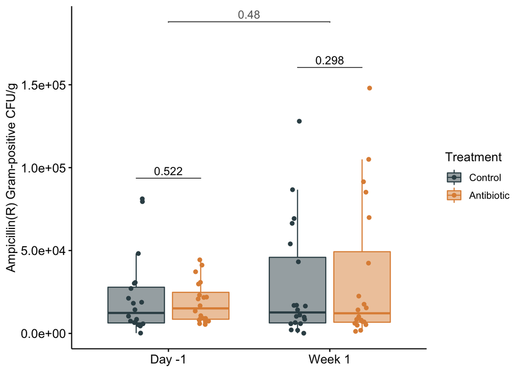

```r
library(ggpubr)
library(ggsci)
GPamp_boxplot = counts_CFU %>%
  dplyr::filter(`GP_Amp_CFU.g` %notin% NA) %>%
  dplyr::filter(study_ID %notin% "MA027") %>%
  ggboxplot(x = "Time_tx", y = "GP_Amp_CFU.g", color = "Treatment", palette = "jama",
            fill = "Treatment", add = c("jitter"), notch = F, outlier.shape = NA) +
  labs(x = "Time to treatment", y = "Ampicillin(R) Gram-positive CFU/g") +
  scale_fill_jama(alpha = 0.5) + theme(legend.position="right") +
  scale_y_continuous(labels = function(x) format(x, scientific = TRUE)) +
  theme(axis.title.x = element_blank()) +
  stat_pvalue_manual(stat.test,  label = "p", tip.length = 0) +
  geom_signif(aes(y = `GP_Amp_CFU.g`, x = Time_tx),
              comparisons = list(c("Day -1","Week 1")),
              test = "wilcox.test", test.args=list(alternative = "less", var.equal = FALSE, paired=FALSE),
              color = "gray40", tip_length = 0.002, y_position = c(1.8e+05))
GPamp_boxplot
```

#GP Ampicillin percentage Percentage calculated over the total of Gram-positive per sample

##Average Gram-positives resistant to ampicillin by treatment and time point

```r
counts_CFU %>%
  dplyr::filter(`GP_Amp_per` %notin% NA, study_ID %notin% "MA027", Time_tx %notin% "Week 11") %>%
  group_by(Treatment, Time_tx) %>%
  summarise(totaGN = mean(`GP_Amp_per`))
```

| Treatment | Time_tx | totaGN |
| --- | --- | --- |
| Control | Day -1 | 3.2485 |
| Control | Week 1 | 4.3645 |
| Antibiotic | Day -1 | 3.9415 |
| Antibiotic | Week 1 | 7.6765 |

##Difference between time-points per treatment group

```r
library(dplyr)
library(rstatix)
`%notin%` <- Negate(`%in%`)

stat.test <- counts_CFU %>%
  dplyr::filter(`GP_Amp_per` %notin% NA) %>%
  dplyr::filter(study_ID %notin% "MA027") %>%
  dplyr::group_by(Treatment) %>%
  rstatix::wilcox_test(`GP_Amp_per` ~ Time_tx, alternative = "g", paired = T) %>%
    rstatix::adjust_pvalue(method = "none") %>%
  rstatix::add_significance("p")
stat.test
```

| Treatment | .y. | group1 | group2 | n1 | n2 | statistic | p | p.adj | p.signif |
| --- | --- | --- | --- | --- | --- | --- | --- | --- | --- |
| Control | GP_Amp_per | Day -1 | Week 1 | 20 | 20 | 99 | 0.594 | 0.594 | ns |
| Antibiotic | GP_Amp_per | Day -1 | Week 1 | 20 | 20 | 67 | 0.925 | 0.925 | ns |

##Difference between treatments by time point

```r
library(dplyr)
library(rstatix)
`%notin%` <- Negate(`%in%`)

stat.test <- counts_CFU %>%
  dplyr::filter(`GP_Amp_per` %notin% NA) %>%
  dplyr::filter(study_ID %notin% "MA027") %>%
  dplyr::filter(Time_tx %in% c("Day -1", "Week 1")) %>%
  dplyr::group_by(Time_tx) %>%
  rstatix::wilcox_test(`GP_Amp_per` ~ Treatment, alternative = "less", paired = T) %>%
    rstatix::adjust_pvalue(method = "none") %>%
  rstatix::add_significance("p") %>%
  add_xy_position(x = "Time_tx", dodge = 0.8)
stat.test
```

| Time_tx | .y. | group1 | group2 | n1 | n2 | statistic | p | p.adj | p.signif | y.position | groups | x | xmin | xmax |
| --- | --- | --- | --- | --- | --- | --- | --- | --- | --- | --- | --- | --- | --- | --- |
| Day -1 | GP_Amp_per | Control | Antibiotic | 20 | 20 | 87 | 0.2610 | 0.2610 | ns | 15.2916 |  | 1 | 0.8 | 1.2 |
| Week 1 | GP_Amp_per | Control | Antibiotic | 20 | 20 | 58 | 0.0413 | 0.0413 | * | 35.4416 |  | 2 | 1.8 | 2.2 |

##Gram-positives resistant to ampicillin percentage plot

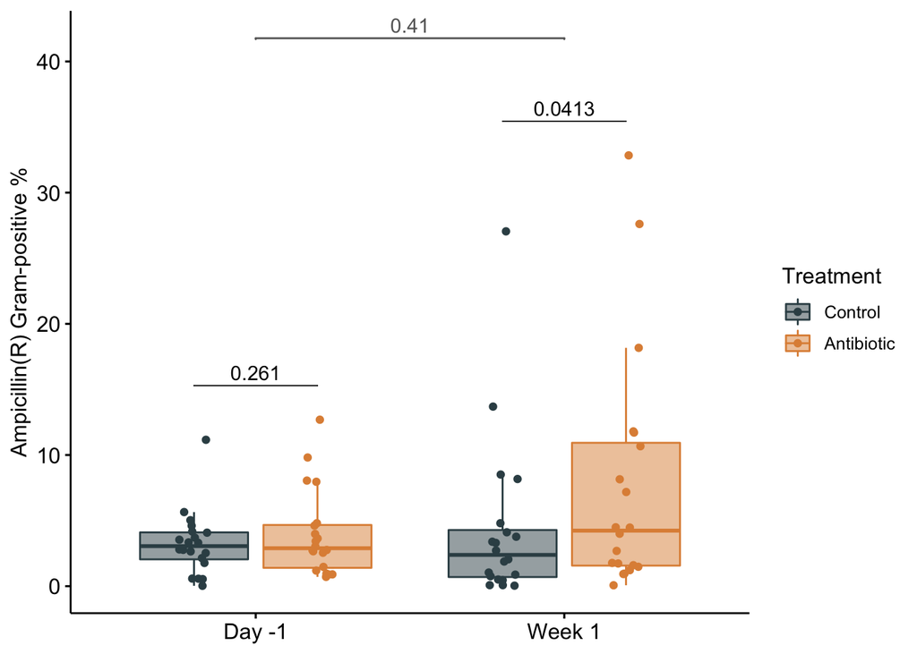

```r
library(ggpubr)
library(ggsci)
GPamp_boxplot_per = counts_CFU %>%
  dplyr::filter(`GP_Amp_per` %notin% NA) %>%
  dplyr::filter(study_ID %notin% "MA027") %>%
  ggboxplot(x = "Time_tx", y = "GP_Amp_per", color = "Treatment", palette = "jama",
            fill = "Treatment", add = c("jitter"), notch = F, outlier.shape = NA) +
  labs(x = "Time to treatment", y = "Ampicillin(R) Gram-positive %") +
  scale_fill_jama(alpha = 0.5) + theme(legend.position="right") +
  theme(axis.title.x = element_blank()) +
  stat_pvalue_manual(stat.test,  label = "p", tip.length = 0) +
  geom_signif(aes(y = `GP_Amp_per`, x = Time_tx),
              comparisons = list(c("Day -1","Week 1")),
              test = "wilcox.test", test.args=list(alternative = "less", var.equal = FALSE, paired=FALSE),
              color = "gray40", tip_length = 0.002, y_position = c(40))
GPamp_boxplot_per
```

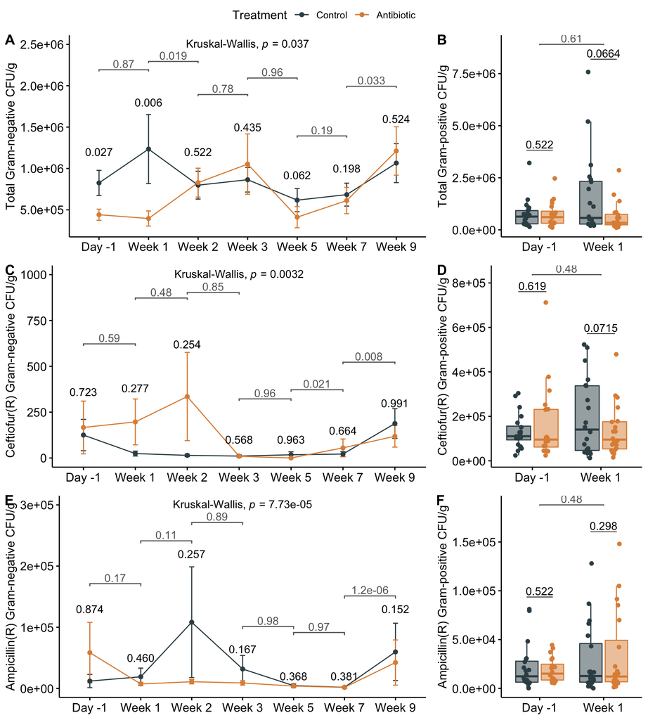

```r
culture_plots <- ggarrange(total_line, GPtotal_boxplot, cef_line, GPcef_boxplot, amp_line, GPamp_boxplot, nrow = 3,ncol = 2, common.legend = T, labels = c("A","B","C","D","E","F"), widths = c(1,.5,1,.5,1,.5))
culture_plots
```

```r
setwd("/Users/karlavasco/OneDrive\ -\ Michigan\ State\ University/Manning_lab/Mastitis_project/figures/culture")
ggsave("culture_plots_KW.png", plot = culture_plots, width = 9, height = 12)
```

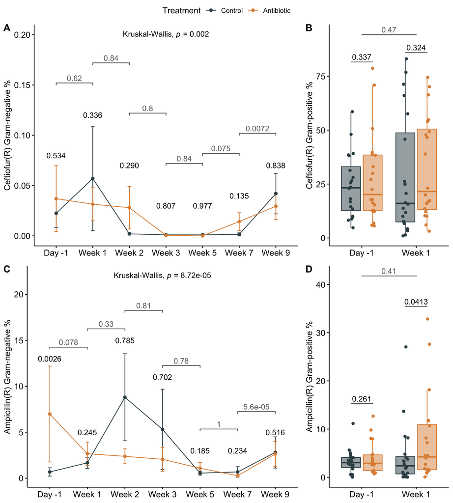

```r
culture_plots_per <- ggarrange(cef_line_per, GPcef_boxplot_per, amp_line_per, GPamp_boxplot_per, nrow = 2,ncol = 2, common.legend = T, labels = c("A","B","C","D"), widths = c(1,.5,1,.5))
culture_plots_per
```

```r
setwd("/Users/karlavasco/OneDrive\ -\ Michigan\ State\ University/Manning_lab/Mastitis_project/figures/culture")
ggsave("culture_plots_res_per.png", plot = culture_plots_per, width = 9, height = 9)
```

#Comparison percentage of Gram-positive resistant to ceftiofur vs. ampicillin within samples

```r
wilcox.test(counts_CFU$GP_Cef_per, counts_CFU$GP_Amp_per)
```

```
##
##  Wilcoxon rank sum test with continuity correction
##
## data:  counts_CFU$GP_Cef_per and counts_CFU$GP_Amp_per
## W = 5856, p-value < 2.2e-16
## alternative hypothesis: true location shift is not equal to 0
```

#Comparison percentage of Gram-negative resistant to ceftiofur vs. ampicillin within samples

```r
wilcox.test(counts_CFU$GN_Cef_per, counts_CFU$GN_Amp_per)
```

```
##
##  Wilcoxon rank sum test with continuity correction
##
## data:  counts_CFU$GN_Cef_per and counts_CFU$GN_Amp_per
## W = 7900, p-value < 2.2e-16
## alternative hypothesis: true location shift is not equal to 0
```

#Comparison prevalence Gram-positive ceftiofur resistant between treatments

```r
antibiotic <- counts_CFU %>% filter(Treatment %in% "Antibiotic",  Time_tx %in% c("Day -1", "Week 1"))
control <- counts_CFU %>% filter(Treatment %in% "Control", Time_tx %in% c("Day -1", "Week 1"))

prevalence_GPcef_antibiotic <- ifelse(antibiotic$GP_Cef_per>0,1,0)
prevalence_GPcef_control <- ifelse(control$GP_Cef_per>0,1,0)

wilcox.test(prevalence_GPcef_antibiotic, prevalence_GPcef_control)
```

```
##
##  Wilcoxon rank sum test with continuity correction
##
## data:  prevalence_GPcef_antibiotic and prevalence_GPcef_control
## W = 800, p-value = NA
## alternative hypothesis: true location shift is not equal to 0
```

#Comparison prevalence Gram-positive ampicillin resistant between treatments

```r
prevalence_GPamp_antibiotic <- ifelse(antibiotic$GP_Amp_per>0,1,0)
#prevalence_GPamp_antibiotic[is.na(prevalence_GPamp_antibiotic)] = 0

prevalence_GPamp_control <- ifelse(control$GP_Amp_per>0,1,0)
#prevalence_GPamp_control[is.na(prevalence_GPamp_control)] = 0

wilcox.test(prevalence_GPamp_antibiotic, prevalence_GPamp_control)
```

```
##
##  Wilcoxon rank sum test with continuity correction
##
## data:  prevalence_GPamp_antibiotic and prevalence_GPamp_control
## W = 800, p-value = NA
## alternative hypothesis: true location shift is not equal to 0
```

#Comparison prevalence Gram-negative ceftiofur resistant between treatments

```r
antibiotic_GN <- counts_CFU %>% filter(Treatment %in% "Antibiotic",  Time_tx %notin% c("Week 11"))
control_GN <- counts_CFU %>% filter(Treatment %in% "Control", Time_tx %notin% c("Week 11"))

prevalence_GNcef_antibiotic <- ifelse(antibiotic_GN$GN_Cef_per>0,1,0)
prevalence_GNcef_antibiotic[is.na(prevalence_GNcef_antibiotic)] = 0

prevalence_GNcef_control <- ifelse(control_GN$GN_Cef_per>0,1,0)
prevalence_GNcef_control[is.na(prevalence_GNcef_control)] = 0

wilcox.test(prevalence_GNcef_antibiotic, prevalence_GNcef_control)
```

```
##
##  Wilcoxon rank sum test with continuity correction
##
## data:  prevalence_GNcef_antibiotic and prevalence_GNcef_control
## W = 9901.5, p-value = 0.6859
## alternative hypothesis: true location shift is not equal to 0
```

#Comparison prevalence Gram-negative ampicillin resistant between treatments

```r
prevalence_GNamp_antibiotic <- ifelse(antibiotic_GN$GN_Amp_per>0,1,0)
prevalence_GNamp_antibiotic[is.na(prevalence_GNamp_antibiotic)] = 0

prevalence_GNamp_control <- ifelse(control_GN$GN_Amp_per>0,1,0)
prevalence_GNamp_control[is.na(prevalence_GNamp_control)] = 0

wilcox.test(prevalence_GNamp_antibiotic, prevalence_GNamp_control)
```

```
##
##  Wilcoxon rank sum test with continuity correction
##
## data:  prevalence_GNamp_antibiotic and prevalence_GNamp_control
## W = 9774, p-value = 0.906
## alternative hypothesis: true location shift is not equal to 0
```

#Comparison variation of CFU/g Gram-negative resistant to ampicillin

```r
GN_counts <- counts_CFU %>% dplyr::filter(study_ID %notin% "MA027", Time_tx %notin% "Week 11")
kruskal.test(GN_counts$GN_Amp_CFU.g ~ GN_counts$Time_tx)
```

```
##
##  Kruskal-Wallis rank sum test
##
## data:  GN_counts$GN_Amp_CFU.g by GN_counts$Time_tx
## Kruskal-Wallis chi-squared = 33.098, df = 6, p-value = 1.004e-05
```

#Comparison variation of CFU/g Gram-negative resistant to ceftiofur

```r
kruskal.test(GN_counts$GN_Cef_CFU.g ~ GN_counts$Time_tx)
```

```
##
##  Kruskal-Wallis rank sum test
##
## data:  GN_counts$GN_Cef_CFU.g by GN_counts$Time_tx
## Kruskal-Wallis chi-squared = 19.677, df = 6, p-value = 0.00316
```

#Comparison variation of % Gram-negative resistant to ceftiofur

```r
kruskal.test(GN_counts$GN_Cef_per ~ GN_counts$Time_tx)
```

```
##
##  Kruskal-Wallis rank sum test
##
## data:  GN_counts$GN_Cef_per by GN_counts$Time_tx
## Kruskal-Wallis chi-squared = 21.561, df = 6, p-value = 0.001454
```

#Comparison variation of % Gram-negative resistant to ampicillin

```r
kruskal.test(GN_counts$GN_Amp_per ~ GN_counts$Time_tx)
```

```
##
##  Kruskal-Wallis rank sum test
##
## data:  GN_counts$GN_Amp_per by GN_counts$Time_tx
## Kruskal-Wallis chi-squared = 23.041, df = 6, p-value = 0.0007829
```

#CEFTIOFUR resistant isolates

```r
#Import tables
setwd("~/OneDrive - Michigan State University/Manning_lab/Mastitis_project/GitHub/data/")
cef_strains <- read.csv("ceftiofur_resistant_isolates.csv")
cef_strains$Treatment <- factor(cef_strains$Treatment, levels = c("Control", "Antibiotic"))
```

#Number of isolates per treatment

```r
cef_strains %>%
  group_by(Treatment) %>%
  summarise(total_isolates=sum(Isolates))
```

| Treatment | total_isolates |
| --- | --- |
| Control | 72 |
| Antibiotic | 74 |

#Plot showing the number of isolates per sampling point and treatment group

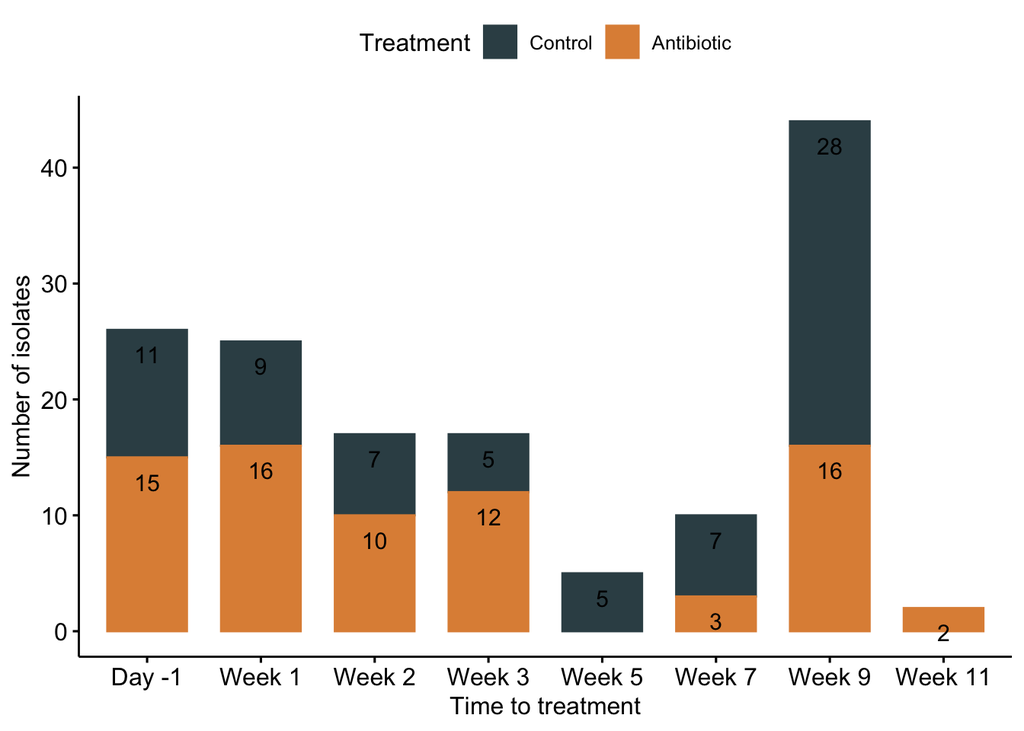

```r
cef_strains$Time_tx <- factor(cef_strains$Time_tx, levels = c("Day -1", "Week 1", "Week 2", "Week 3", "Week 5", "Week 7", "Week 9", "Week 11"))

cef_strains_number <-cef_strains %>%
  group_by(Time_tx, Treatment) %>%
  summarise(total_isolates=sum(Isolates)) %>%
  ggbarplot(x = "Time_tx", y = "total_isolates", color = "Treatment", fill="Treatment",
            lab.pos = "in", label = T, lab.col = "black",
            ylab = "Number of isolates",
            xlab = "Time to treatment",
            palette = "jama")
cef_strains_number
```